# projet r shiny

GreenTech solutions

2024-10-13

# Rapport d’évaluation de l’impact de la classe DPE sur les consommations électriques des logements

Le réchauffement climatique est l’un des enjeux principaux de la société actuelle. Bien que nous réduisions progressivement nos émissions de gaz à effet de serre et nos déchets quotidiens, notre consommation d’énergie doit, elle aussi, diminuer. L’un des meilleurs moyens pour réduire cette consommation est le Diagnostic de Performance Énergétique (DPE), qui nous permet de savoir si nos habitations consomment beaucoup d’énergie ou non. Cela nous permet de nous interroger sur les distinctions entre les différents types de logements et leur étiquette DPE. À travers cette étude, nous vous informerons sur la situation du département du Rhône à travers différentes statistiques liées au domaine de l’énergie.

Notre étude sera basée sur l’observation des logements du département du Rhône, avec une population observée de 284 905 logements. Nous disposons à la fois de données quantitatives, telles que les émissions de gaz à effet de serre, la surface habitable, le coût total des énergies utilisées, et de données qualitatives, telles que le type d’énergie principal, les communes, la qualité de l’isolation, l’étiquette GES, l’étiquette DPE, le type de bâtiment et le type d’énergie de chauffage.

## Analyse globale des données du Rhône

Le Rhône est un département de la région Auvergne-Rhône-Alpes. Avant de commencer à explorer les différents croisements de données, examinons d’abord les premières visualisations simples de nos données.

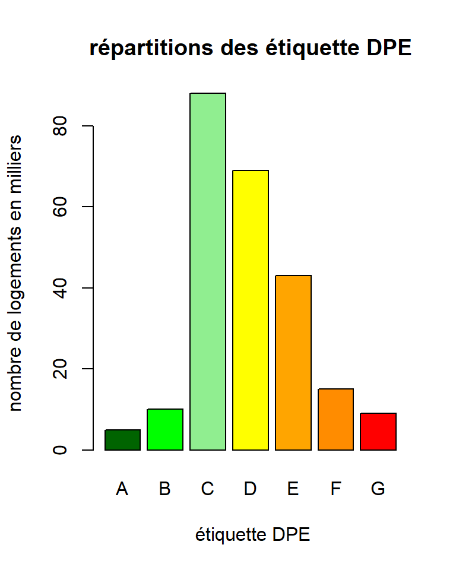

À l’aide de ce graphique représentant le nombre de logements (en milliers) en fonction de l’étiquette DPE, nous constatons que les logements du Rhône sont principalement classés C et D, tandis que très peu sont classés A et B. Cela nous indique que peu de logements dans ce département sont très performants sur le plan énergétique.

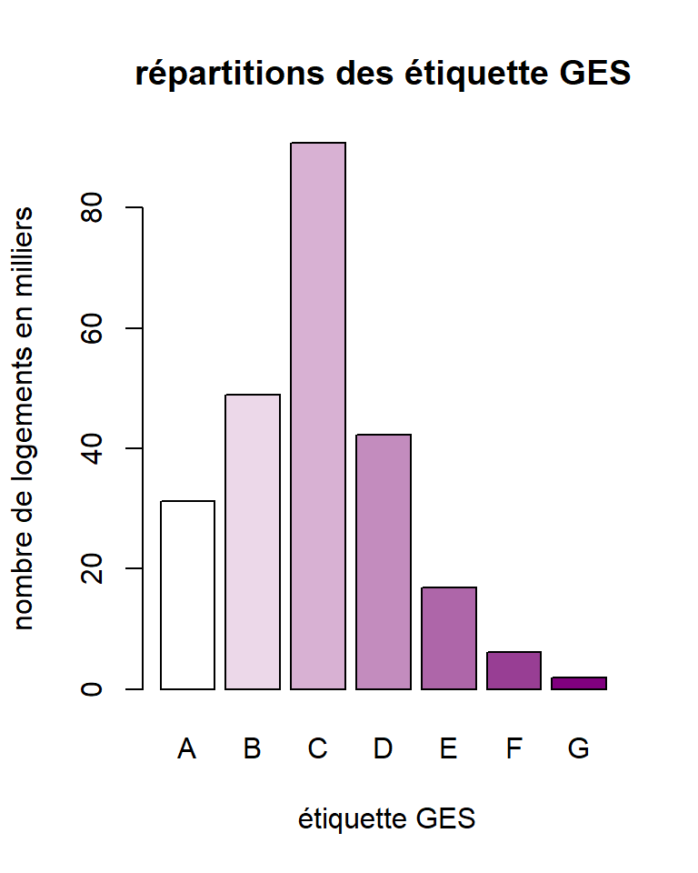

Ce graphique du nombre de logements (en milliers) en fonction des étiquettes GES montre que les logements sont principalement classés C, B ou D, et que très peu sont classés F et G. Cela indique que peu de logements génèrent de fortes émissions de gaz à effet de serre.

| Var1 | Freq |
| --- | --- |
| Gaz naturel | 104700 |
| Électricité | 79734 |
| Réseau de Chauffage urbain | 31730 |
| Fioul domestique | 4424 |
| Bois – Bûches | 1831 |
| Bois – Granulés (pellets) ou briquettes | 1359 |
| GPL | 437 |
| Propane | 132 |
| Bois – Plaquettes d’industrie | 19 |
| Charbon | 14 |
| Bois – Plaquettes forestières | 12 |
| Électricité d’origine renouvelable utilisée dans le bâtiment | 4 |
| Butane | 2 |

Ce tableau nous montre la répartition des différents moyens de chauffage des habitants du Rhône. On peut voir que le plus utilisé est le gaz naturel, tandis que le moins utilisé est le butane.

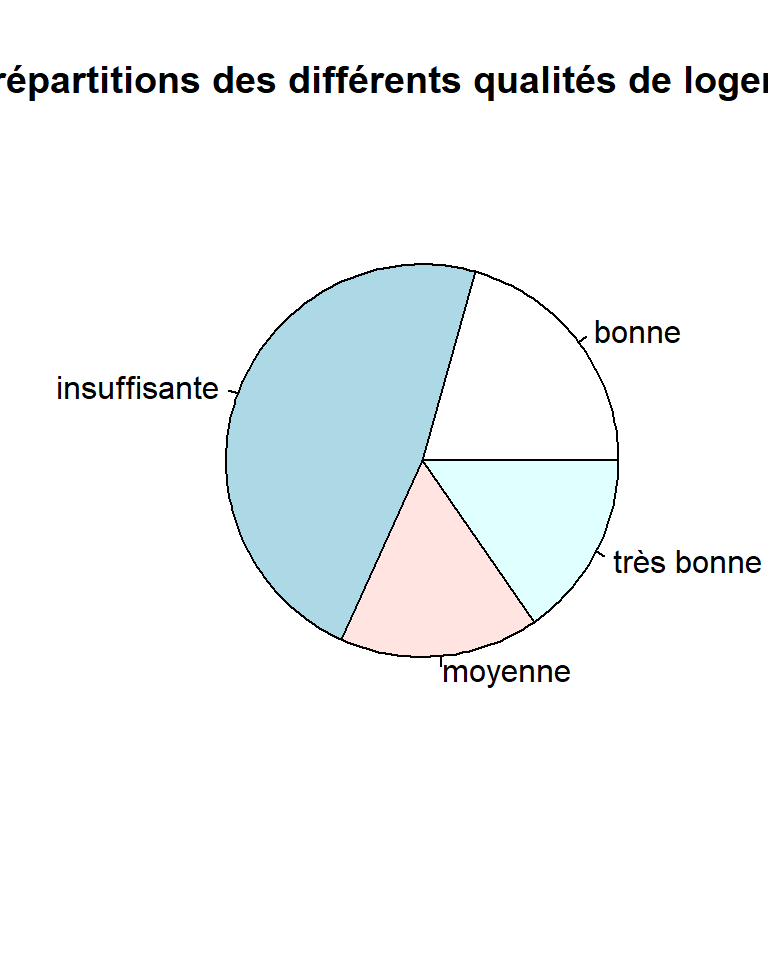

## Analyses croisées

Après avoir pu réaliser une analyse globale de nos données, qu’est-ce que cette base de données peut nous apprendre ?

Tout d’abord, observons l’un des sujets principaux : l’étiquette DPE a-t-elle une influence sur les émissions de gaz à effet de serre ?

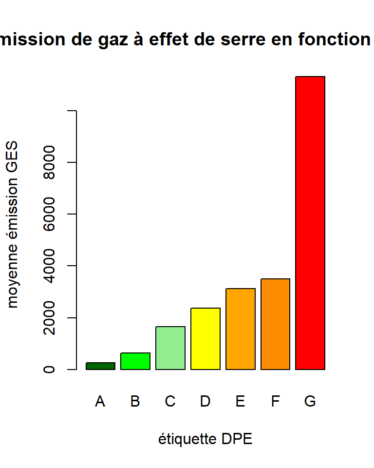

Ce graphique nous permet de constater que la performance des logements a un fort impact sur les émissions de gaz à effet de serre.

| Type_bâtiment | pts_DPE |
| --- | --- |
| appartement | 3.115921 |
| immeuble | 3.342026 |
| maison | 3.014573 |

|  | Type_énergie_principale_chauffage | Emission_GES_5_usages |
| --- | --- | --- |
| 3 | Bois – Plaquettes d’industrie | 515.8000 |
| 7 | Électricité | 603.6519 |
| 2 | Bois – Granulés (pellets) ou briquettes | 635.5062 |
| 4 | Bois – Plaquettes forestières | 759.4500 |
| 8 | Électricité d’origine renouvelable utilisée dans le bâtiment | 1074.1250 |
| 1 | Bois – Bûches | 1381.0673 |
| 12 | Propane | 2223.5394 |
| 13 | Réseau de Chauffage urbain | 2744.6350 |
| 10 | Gaz naturel | 3131.8576 |
| 11 | GPL | 5959.5966 |
| 5 | Butane | 7883.4000 |
| 9 | Fioul domestique | 9124.0413 |
| 6 | Charbon | 11722.7786 |

| Type_énergie_principale_chauffage | pts_GES | etiquette_DPE |
| --- | --- | --- |
| Bois – Bûches | 5 | B |
| Bois – Granulés (pellets) ou briquettes | 5 | B |
| Bois – Plaquettes d’industrie | 5 | B |
| Bois – Plaquettes forestières | 5 | B |
| Butane | 2 | E |
| Charbon | 0 | G |
| Électricité | 5 | B |
| Électricité d’origine renouvelable utilisée dans le bâtiment | 5 | B |
| Fioul domestique | 1 | F |
| Gaz naturel | 3 | D |
| GPL | 3 | D |
| Propane | 3 | D |
| Réseau de Chauffage urbain | 4 | C |

| Type_énergie_principale_chauffage | pts_DPE | etiquette_DPE |
| --- | --- | --- |
| Bois – Bûches | 3 | D |
| Bois – Granulés (pellets) ou briquettes | 4 | C |
| Bois – Plaquettes d’industrie | 4 | C |
| Bois – Plaquettes forestières | 3 | D |
| Butane | 2 | E |
| Charbon | 0 | G |
| Électricité | 3 | D |
| Électricité d’origine renouvelable utilisée dans le bâtiment | 3 | D |
| Fioul domestique | 1 | F |
| Gaz naturel | 3 | D |
| GPL | 3 | D |
| Propane | 3 | D |
| Réseau de Chauffage urbain | 3 | D |

Au niveau de la performance des logements, nous pouvons observer à l’aide de ce tableau quel type de chauffage les personnes utilisent en fonction de leur étiquette DPE. En moyenne, le chauffage le plus utilisé par les personnes ayant une performance énergétique correcte est le bois granulé et les plaquettes d’industrie. En revanche, les personnes dont l’étiquette est classée comme passoire énergétique utilisent principalement le fioul domestique.

## Conclusion de l’analyse

Pour conclure notre analyse sur les logements du Rhône, nous avons pu observer les différents rapports entre l’isolation énergétique et les émissions de gaz à effet de serre. La région du Rhône nous a permis de constater que les logements ayant une mauvaise isolation thermique font partie de ceux qui émettent le plus de gaz à effet de serre. Les principaux progrès à réaliser pour la région consistent à améliorer les classifications DPE des logements et à renouveler le moyen de chauffage principal.

Nous mettons à disposition un site réalisé en R Shiny, afin que vous puissiez effectuer différentes recherches sur la région avec les données qui nous ont été fournies. Celles-ci sont principalement géographiques pour vous permettre d’obtenir diverses informations sur les points géographiques.